# Loading final assignmment corpora

This notebook demonstrates loading Conc corpora for the final assignment datasets.

You can use these corpora for exploratory analysis.

## Import functionality to load/build and start working with corpora

```python
import pandas as pd
import numpy as np

from conc.corpus import Corpus
from conc.listcorpus import ListCorpus
from conc.conc import Conc
from conc.corpora import list_corpora
from conc.core import get_stop_words
```

## Set paths

Location of corpora and source data. You don't need to change these to load corpora already available on the JupyterHub server.

```python
source_path = f'/srv/source-data/'
save_path = f'/srv/corpora/'
```

## List available corpora

To view corpora available at `save_path`, run ...

```python
list_corpora(save_path)
```

| corpus | name | format | date_created | document_count | token_count |
| --- | --- | --- | --- | --- | --- |
| "papers-past-genres.corpus" | "Papers Past Genres" | "Corpus" | "2026-05-11 15:13:33" | "1,861" | "1,204,312" |
| "clinton-subcorpus.corpus" | "Clinton Subcorpus" | "Corpus" | "2025-07-20 22:04:57" | "36" | "132,573" |
| "trump-subcorpus.corpus" | "Trump Subcorpus" | "Corpus" | "2025-07-20 22:04:54" | "82" | "521,989" |
| "tweet-sentiment.corpus" | "Tweet Sentiment" | "Corpus" | "2026-05-11 14:36:27" | "59,899" | "1,320,918" |
| "bnc.listcorpus" | "BNC" | "List Corpus" | "2025-07-09 08:54:00" | "4,049" | "113,536,056" |
| "garden-party.corpus" | "Garden Party Corpus" | "Corpus" | "2025-07-10 13:30:44" | "15" | "74,664" |
| "introduce-yourself.corpus" | "Introduce Yourself" | "Corpus" | "2025-07-11 17:00:14" | "96" | "35,229" |
| "rnz.listcorpus" | "RNZ Corpus" | "List Corpus" | "2025-07-10 19:22:40" | "458,113" | "143,331,518" |
| "brown.corpus" | "Brown Corpus" | "Corpus" | "2025-07-10 13:30:09" | "500" | "1,138,566" |
| "toy.corpus" | "Toy Corpus" | "Corpus" | "2025-07-10 13:30:02" | "6" | "38" |
| "labour-nz-first-coalition.corpus" | "Labour-NZ First Coalition" | "Corpus" | "2025-07-09 23:20:16" | "325" | "655,092" |
| "national-led.corpus" | "National-led" | "Corpus" | "2025-07-09 23:20:23" | "391" | "787,785" |
| "rnz-climate-international.corpus" | "RNZ Climate International" | "Corpus" | "2025-07-17 23:24:39" | "4,948" | "2,414,005" |
| "rnz-climate-national.corpus" | "RNZ Climate National" | "Corpus" | "2025-07-17 23:24:48" | "6,104" | "3,962,664" |
| "rnz-climate.corpus" | "RNZ Climate Corpus" | "Corpus" | "2025-07-17 23:22:57" | "11,052" | "6,376,669" |
| "quake-stories-v2.corpus" | "Quake Stories v2" | "Corpus" | "2025-07-02 09:42:43" | "487" | "472,876" |
| "baby-bnc.listcorpus" | "Baby BNC" | "List Corpus" | "2025-07-09 08:44:05" | "182" | "4,674,632" |
| "gutenberg.corpus" | "Gutenberg Corpus" | "Corpus" | "2025-07-10 13:30:42" | "18" | "2,546,286" |
| "machine-generated-essays.corpus" | "Machine-generated Essays" | "Corpus" | "2026-05-11 15:15:28" | "6,958" | "4,321,955" |
| "reuters.corpus" | "Reuters Corpus" | "Corpus" | "2025-07-10 13:30:18" | "10,788" | "1,552,919" |
| "brown.listcorpus" | "Brown Corpus" | "List Corpus" | "2025-07-10 13:30:09" | "500" | "1,138,566" |

## Loading a corpus or list corpus

You don't have to use `corpus` for the variable name. It may be helpful to use a more descriptive name if you are working with multiple corpora (e.g. `essay_corpus`)

```python
corpus = Corpus().load(f'{save_path}tweet-sentiment.corpus')
```

```python
corpus.summary()
```

Corpus Summary

| Attribute | Value |
| --- | --- |
| Name | Tweet Sentiment |
| Description | Corpus of tweets for sentiment classification from cardiffnlp/tweet_eval. See https://huggingface.co/datasets/cardiffnlp/tweet_eval |
| Date Created | 2026-05-11 14:36:27 |
| Conc Version | 0.1.13 |
| Corpus Path | /srv/corpora/tweet-sentiment.corpus |
| Document Count | 59,899 |
| Token Count | 1,320,918 |
| Word Token Count | 1,124,587 |
| Unique Tokens | 61,343 |
| Unique Word Tokens | 61,191 |

## Explore the corpus

Use methods from Weeks 1 and 2 of the course to explore the corpus

```python
conc = Conc(corpus)
```

```python
stop_words = get_stop_words(save_path = save_path)
```

```python
conc.frequencies(exclude_punctuation = False,
                 page_current = 1,
                 page_size = 20,
                 normalize_by=1000,
                 exclude_tokens = stop_words
                 ).display()
```

Frequencies

Frequencies of word and punctuation tokens, Tweet Sentiment

| Rank | Token | Frequency | Normalized Frequency |
| --- | --- | --- | --- |
| 1 | . | 38,378 | 29.05 |
| 2 | " | 30,586 | 23.16 |
| 3 | @user | 25,722 | 19.47 |
| 4 | , | 22,730 | 17.21 |
| 5 | # | 22,614 | 17.12 |
| 6 | ! | 19,563 | 14.81 |
| 7 | ? | 9,096 | 6.89 |
| 8 | - | 8,967 | 6.79 |
| 9 | ... | 8,668 | 6.56 |
| 10 | : | 8,116 | 6.14 |
| 11 | tomorrow | 7,550 | 5.72 |
| 12 | day | 4,120 | 3.12 |
| 13 | & | 3,944 | 2.99 |
| 14 | going | 3,319 | 2.51 |
| 15 | night | 3,141 | 2.38 |
| 16 | like | 3,101 | 2.35 |
| 17 | ( | 3,006 | 2.28 |
| 18 | friday | 2,905 | 2.20 |
| 19 | ) | 2,899 | 2.19 |
| 20 | 1st | 2,758 | 2.09 |

Report based on word and punctuation tokens  
Tokens excluded from report: 299  
Normalized Frequency is per 1,000 tokens  
Total word and punctuation tokens: 1,320,918  
Unique word and punctuation tokens: 61,044  
Showing 20 rows  
Page 1 of 3053

## Explore more with CSV files

CSV files of the final assignment datasets are also available if you wish to use them to create sub-corpora e.g., by filtering on one of the labels.

The CSVs are called:

- `combined_essays.csv`
- `combined_genres.csv`
- `combined_tweets.csv`

A notebook called `DIGI405 - loading and building corpora.ipynb`, which was provided with the Week 1 lab notebooks, provides details on how to construct Conc corpora and list corpora.

```python
df = pd.read_csv(source_path + "combined_tweets.csv")
```

```python
df.info()
```

```
<class 'pandas.core.frame.DataFrame'>
RangeIndex: 59899 entries, 0 to 59898
Data columns (total 4 columns):
 #   Column      Non-Null Count  Dtype
---  ------      --------------  -----
 0   orig_index  59899 non-null  object
 1   text        59899 non-null  object
 2   label_name  59899 non-null  object
 3   label       59899 non-null  int64
dtypes: int64(1), object(3)
memory usage: 1.8+ MB
```

```python
df.head()
```

|  | orig_index | text | label_name | label |
| --- | --- | --- | --- | --- |
| 0 | train_0 | "QT @user In the original draft of the 7th boo... | positive | 2 |
| 1 | train_1 | "Ben Smith / Smith (concussion) remains out of... | neutral | 1 |
| 2 | train_2 | Sorry bout the stream last night I crashed out... | neutral | 1 |
| 3 | train_3 | Chase Headley's RBI double in the 8th inning o... | neutral | 1 |
| 4 | train_4 | @user Alciato: Bee will invest 150 million in ... | positive | 2 |

## 2.1 Label distribution plot

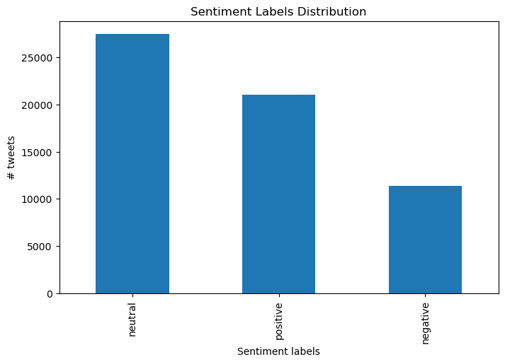

```python
import matplotlib.pyplot as plt
class_each = df['label_name'].value_counts()
plt.figure(figsize=(8, 5))
class_each.plot(kind='bar')
plt.title('Sentiment Labels Distribution')
plt.xlabel('Sentiment labels')
plt.ylabel('# tweets')
plt.show()
```

## 2.2. EDA – Tweet Word Counts Distribution

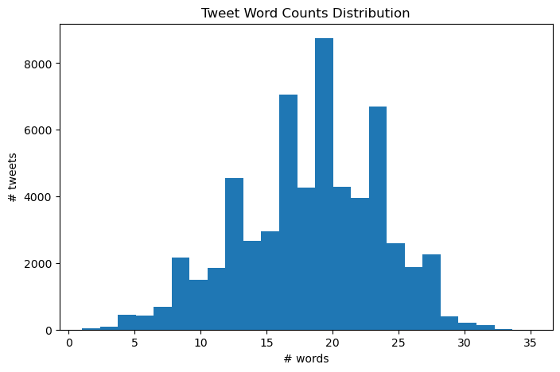

```python
df['character'] = df['text'].astype(str).str.len()
df['word_count'] = df['text'].astype(str).str.split().str.len()
plt.figure(figsize=(8, 5))
plt.hist(df['word_count'], bins=25)
plt.title('Tweet Word Counts Distribution')
plt.xlabel('# words')
plt.ylabel('# tweets')
plt.show()
```

## 2.3 VADER Compound Score Distribution

```python
from vaderSentiment.vaderSentiment import SentimentIntensityAnalyzer
tweetana = SentimentIntensityAnalyzer()
def calcvader(text):
    scores = tweetana.polarity_scores(str(text))
    return pd.Series(scores)
vscores = df['text'].apply(calcvader)
vdf = pd.concat([df.copy(), vscores], axis=1)
```

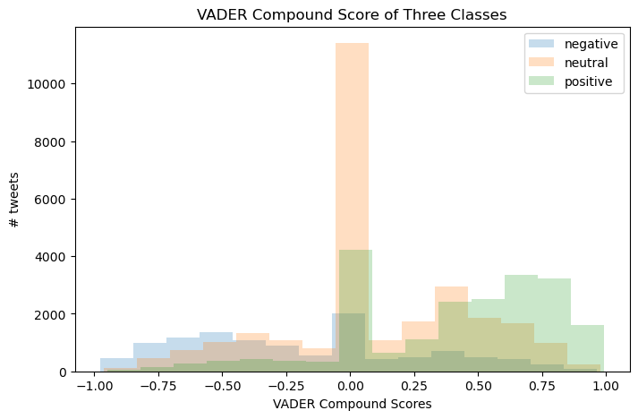

```python
plt.figure(figsize=(8, 5))
for three_label in ['negative', 'neutral', 'positive']:
    subset = vdf[vdf['label_name'] == three_label]
    plt.hist(subset['compound'], bins=15, alpha=0.25, label= three_label)
plt.title('VADER Compound Score of Three Classes')
plt.xlabel('VADER Compound Scores')
plt.ylabel('# tweets')
plt.legend()
plt.show()
```